# Supplementary Code for manuscript entitled - Rabies virus interferon antagonist P protein selectively modulates interferon signalling to inhibit antiviral genes while supporting proviral gene expressi

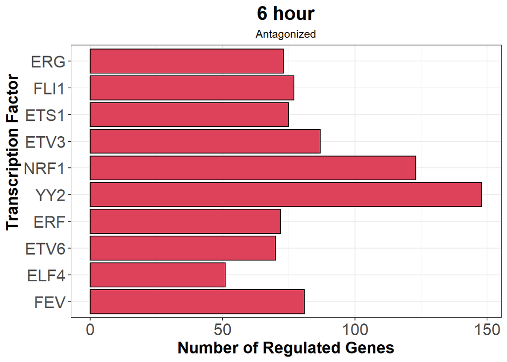

```r
ggplot(Six_hour_ANT_deficit %>%
       arrange(desc(Significance)) %>%
       head(10) %>%
       mutate(TF = reorder(TF, Significance))) +
  aes(x = IRGs, y = TF) +
  geom_col(fill = "#de425b", color = "black") +
  labs(
    title = "6 hour",
    subtitle = "Antagonized",
    x = "Number of Regulated Genes",
    y = "Transcription Factor"
  ) +
  theme_bw() +
  theme(
    axis.text.y = element_text(size = 16),
    axis.text.x = element_text(size = 16),
    axis.title.x = element_text(hjust =0.5 ,size = 16, face = "bold"),
    axis.title.y = element_text(hjust = 0.75, size = 16, face = "bold"),
    plot.title = element_text(hjust = 0.5, size = 19, face = "bold"),
    plot.subtitle = element_text(hjust = 0.5)
  )
```

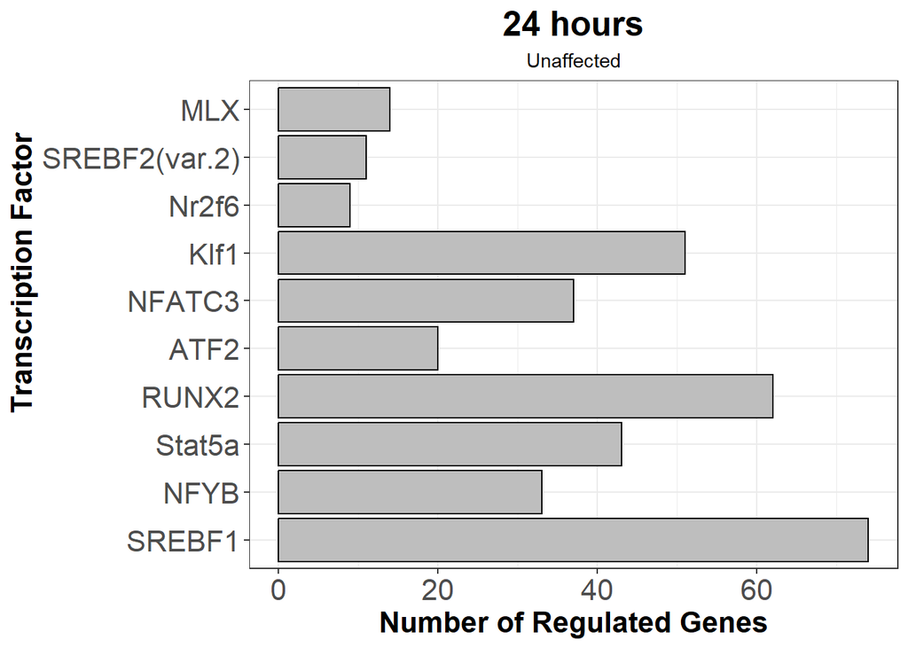

```r
ggplot(TwentyFour_hour_Unaff_deficit %>%
       arrange(desc(Significance)) %>%
       head(10) %>%
       mutate(TF = reorder(TF, Significance))) +
  aes(x = IRGs, y = TF) +
  geom_col(fill = "grey", color = "black") +
  labs(
    title = "24 hours",
    subtitle = "Unaffected",
    x = "Number of Regulated Genes",
    y = "Transcription Factor"
  ) +
  theme_bw() +
  theme(
    axis.text.y = element_text(size = 16),
    axis.text.x = element_text(size = 16),
    axis.title.x = element_text(hjust =0.5 ,size = 16, face = "bold"),
    axis.title.y = element_text(hjust = 0.75, size = 16, face = "bold"),
    plot.title = element_text(hjust = 0.5, size = 19, face = "bold"),
    plot.subtitle = element_text(hjust = 0.5)
  )
```

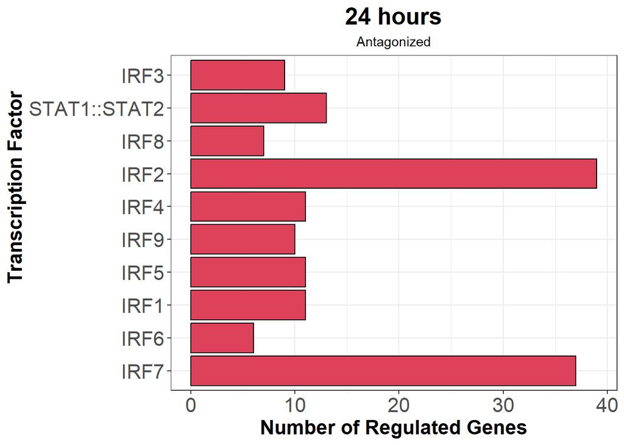

```r
ggplot(TwentyFour_hour_ANT_deficit %>%
       arrange(desc(Significance)) %>%
       head(10) %>%
       mutate(TF = reorder(TF, Significance))) +
  aes(x = IRGs, y = TF) +
  geom_col(fill = "#de425b", color = "black") +
  labs(
    title = "24 hours",
    subtitle = "Antagonized",
    x = "Number of Regulated Genes",
    y = "Transcription Factor"
  ) +
  theme_bw() +
  theme(
    axis.text.y = element_text(size = 16),
    axis.text.x = element_text(size = 16),
    axis.title.x = element_text(hjust =0.5 ,size = 16, face = "bold"),
    axis.title.y = element_text(hjust = 0.75, size = 16, face = "bold"),
    plot.title = element_text(hjust = 0.5, size = 19, face = "bold"),
    plot.subtitle = element_text(hjust = 0.5)
  )
```

```r
merged_1h_antagonized <- One_Antagonized_bed %>%
       left_join(One_hour_ANT_deficit,by = "ID") %>%
  dplyr::filter(!is.na(TF)) %>%
  left_join(One_hour, by = c("Gene" = "SYMBOL"))

merged_1h_unaffected <- One_Unaffected_bed %>%
       left_join(One_hour_Unaff_deficit,by = "ID") %>%
  dplyr::filter(!is.na(TF)) %>%
  left_join(One_hour, by = c("Gene" = "SYMBOL"))

merged_6h_antagonized <- Six_Antagonized_bed %>%
       left_join(Six_hour_ANT_deficit,by = "ID") %>%
  dplyr::filter(!is.na(TF)) %>%
  left_join(Six_hours, by = c("Gene" = "SYMBOL"))

merged_6h_unaffected <- Six_unaffected_bed %>%
       left_join(Six_hour_Unaff_deficit,by = "ID") %>%
  dplyr::filter(!is.na(TF)) %>%
  left_join(Six_hours, by = c("Gene" = "SYMBOL"))

merged_24_antagonized <- Twentyfour_Antagonized_bed %>%
       left_join(TwentyFour_hour_ANT_deficit,by = "ID") %>%
  dplyr::filter(!is.na(TF)) %>%
  left_join(TwentyFour_hours, by = c("Gene" = "SYMBOL"))

merged_24_unaffected <- Twentyfour_Unaffected_bed %>%
       left_join(TwentyFour_hour_Unaff_deficit,by = "ID") %>%
  dplyr::filter(!is.na(TF)) %>%
  left_join(TwentyFour_hours, by = c("Gene" = "SYMBOL"))
```

### Ridgeline plot : Predicted TFs and average fold change of the genes they regulate -

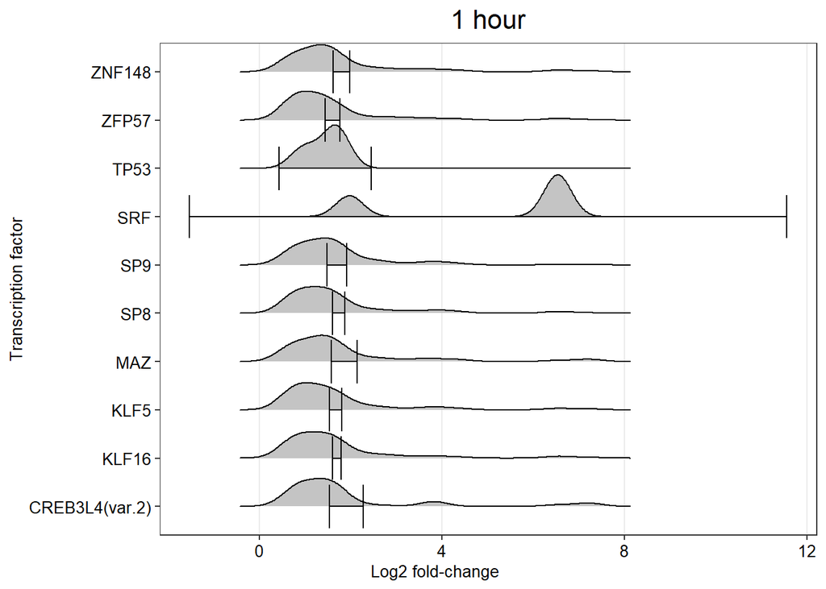

```r
# Ridgeline_1h_unaffected <-
  ggplot(merged_1h_unaffected %>%
         arrange(desc(Significance)) %>%
         filter(TF %in% (merged_1h_unaffected %>%
                        arrange(desc(Significance)) %>%
                        distinct(TF) %>%
                        head(10) %>%
                        pull(TF))),
       aes(x = FLAG_1hr.v.FLAG_0hr.logFC, y = TF, fill = Effect)) +
  geom_density_ridges(alpha = 0.9, scale = 0.9) +
  stat_summary(
    aes(x = FLAG_1hr.v.FLAG_0hr.logFC, y = TF),
    fun.data = "mean_cl_normal",
    geom = "errorbarh",
    height = 0.2,
    color = "black"
  ) +
  scale_fill_manual(values = c("Up" = "grey")) +
  scale_color_manual(values = c("Up" = "black")) +
  ggtitle("1 hour") +
  theme_bw(base_size = 11) +
  theme(
    legend.position = "none",
    panel.grid.major.y = element_blank(),   # remove horizontal gridlines behind ridges
    panel.grid.minor = element_blank(),
    axis.title.x = element_text(size = 10, face = "plain", color = "black", hjust = 0.4),
    axis.title.y = element_text(size = 10, face = "plain", color = "black"),
    axis.text.x = element_text(size = 10, face = "plain", color = "black"),
    axis.text.y = element_text(size = 10, face = "plain", color = "black"),
    plot.title = element_text(size = 16, face = "plain", hjust = 0.5, color = "black")
  ) +
  xlab("Log2 fold-change") +
  ylab("Transcription factor")
```

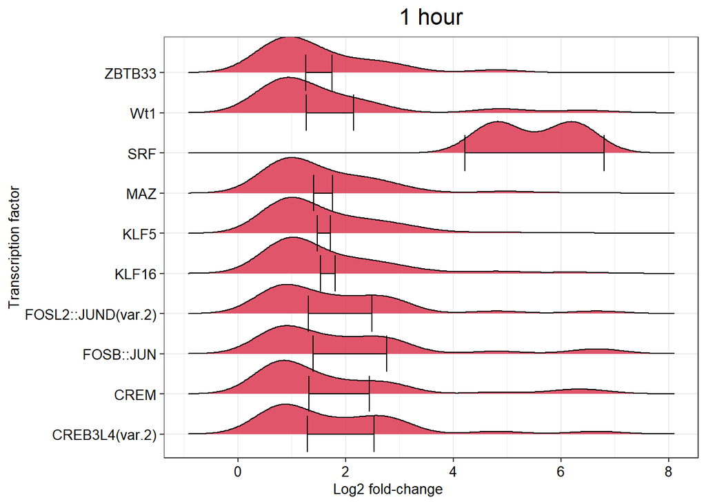

```r
# Ridgeline_1h_antagonized <-
  ggplot(merged_1h_antagonized %>%
         arrange(desc(Significance)) %>%
         filter(TF %in% (merged_1h_antagonized %>%
                        arrange(desc(Significance)) %>%
                        distinct(TF) %>%
                        head(10) %>%
                        pull(TF))),
       aes(x = FLAG_1hr.v.FLAG_0hr.logFC, y = TF, fill = Effect)) +
  geom_density_ridges(alpha = 0.9, scale = 0.9) +
 # geom_jitter(aes(color = Effect), size = 0.9, height = 0.1, alpha = 0.6) +
  stat_summary(
    aes(x = FLAG_1hr.v.FLAG_0hr.logFC, y = TF),
    fun.data = "mean_cl_normal",
    geom = "errorbarh",
    height = 0.2,
    color = "black"
  ) +
  scale_fill_manual(values = c("Up" = "#de425b")) +
  scale_color_manual(values = c("Up" = "black")) +
  ggtitle("1 hour") +
  theme_bw(base_size = 11) +
  theme(
    legend.position = "none",
    axis.title.x = element_text(size = 10, face = "plain", color = "black", hjust = 0.4),
    axis.title.y = element_text(size = 10, face = "plain", color = "black"),
    axis.text.x = element_text(size = 10, face = "plain", color = "black"),
    axis.text.y = element_text(size = 10, face = "plain", color = "black"),
    plot.title = element_text(size = 16, face = "plain", hjust = 0.5, color = "black")
  ) +
  xlab("Log2 fold-change") +
  ylab("Transcription factor")
```

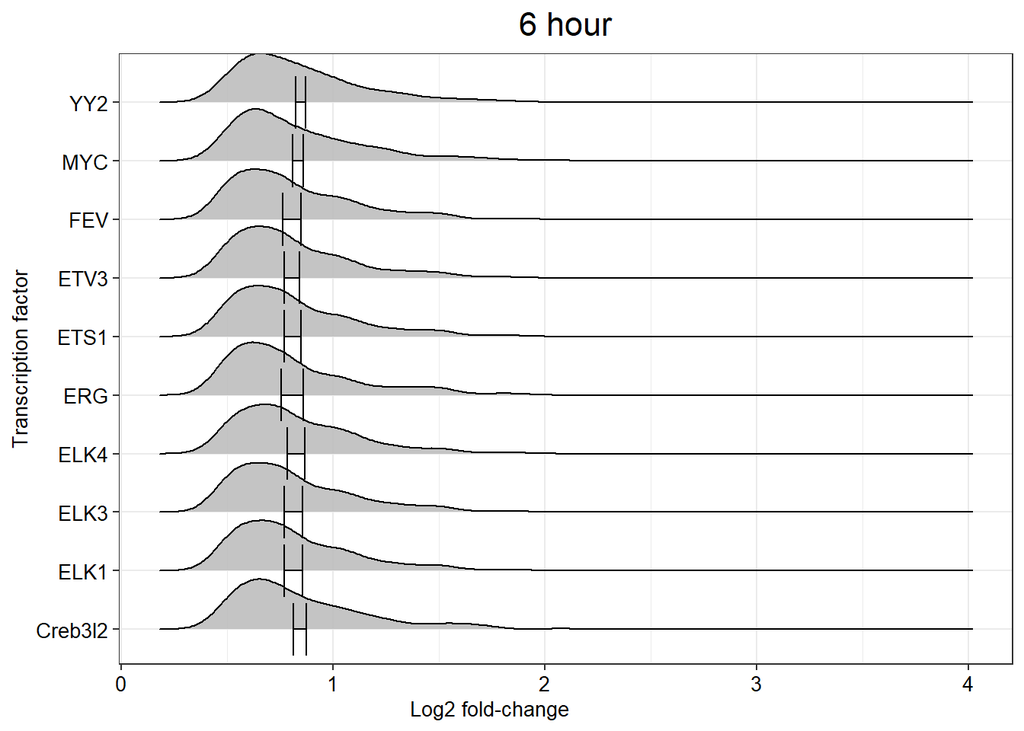

```r
# Ridgeline_6h_unaffected <-
  ggplot(merged_6h_unaffected %>%
         arrange(desc(Significance)) %>%
         filter(TF %in% (merged_6h_unaffected %>%
                        arrange(desc(Significance)) %>%
                        distinct(TF) %>%
                        head(10) %>%
                        pull(TF))),
       aes(x = FLAG_6hr.v.FLAG_0hr.logFC, y = TF, fill = Effect)) +
  geom_density_ridges(alpha = 0.9, scale = 0.9) +
 # geom_jitter(aes(color = Effect), size = 0.9, height = 0.1, alpha = 0.6) +
  stat_summary(
    aes(x = FLAG_6hr.v.FLAG_0hr.logFC, y = TF),
    fun.data = "mean_cl_normal",
    geom = "errorbarh",
    height = 0.2,
    color = "black"
  ) +
  scale_fill_manual(values = c("Up" = "grey")) +
  scale_color_manual(values = c("Up" = "black")) +
  ggtitle("6 hour") +
  theme_bw(base_size = 11) +
  theme(
    legend.position = "none",
    axis.title.x = element_text(size = 10, face = "plain", color = "black", hjust = 0.4),
    axis.title.y = element_text(size = 10, face = "plain", color = "black"),
    axis.text.x = element_text(size = 10, face = "plain", color = "black"),
    axis.text.y = element_text(size = 10, face = "plain", color = "black"),
    plot.title = element_text(size = 16, face = "plain", hjust = 0.5, color = "black")
  ) +
  xlab("Log2 fold-change ") +
  ylab("Transcription factor")
```

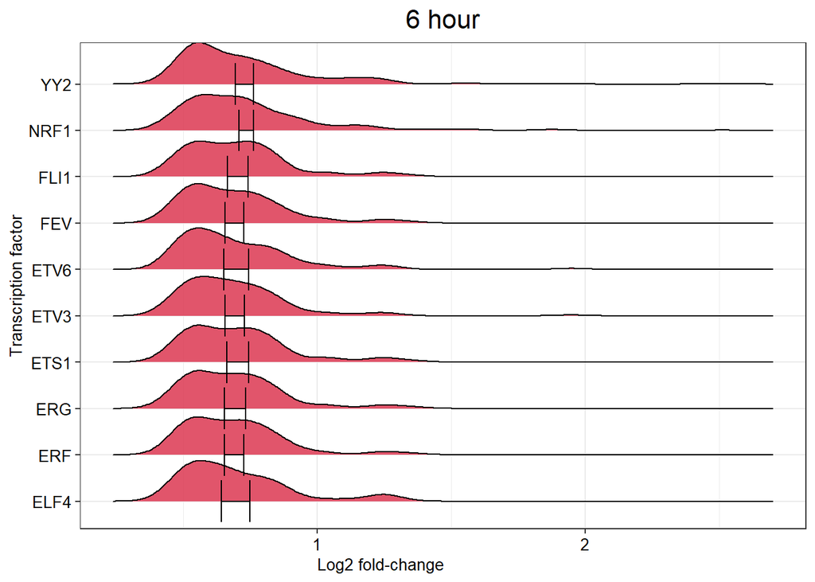

```r
  # Ridgeline_6h_antagonized <-
  ggplot(merged_6h_antagonized %>%
         arrange(desc(Significance)) %>%
         filter(TF %in% (merged_6h_antagonized %>%
                        arrange(desc(Significance)) %>%
                        distinct(TF) %>%
                        head(10) %>%
                        pull(TF))),
       aes(x = FLAG_6hr.v.FLAG_0hr.logFC, y = TF, fill = Effect)) +
  geom_density_ridges(alpha = 0.9, scale = 0.9) +
 # geom_jitter(aes(color = Effect), size = 0.9, height = 0.1, alpha = 0.6) +
  stat_summary(
    aes(x = FLAG_6hr.v.FLAG_0hr.logFC, y = TF),
    fun.data = "mean_cl_normal",
    geom = "errorbarh",
    height = 0.2,
    color = "black"
  ) +
  scale_fill_manual(values = c("Up" = "#de425b")) +
  scale_color_manual(values = c("Up" = "black")) +
  ggtitle("6 hour") +
  theme_bw(base_size = 11) +
  theme(
    legend.position = "none",
    axis.title.x = element_text(size = 10, face = "plain", color = "black", hjust = 0.4),
    axis.title.y = element_text(size = 10, face = "plain", color = "black"),
    axis.text.x = element_text(size = 10, face = "plain", color = "black"),
    axis.text.y = element_text(size = 10, face = "plain", color = "black"),
    plot.title = element_text(size = 16, face = "plain", hjust = 0.5, color = "black")
  ) +
  xlab("Log2 fold-change ") +
  ylab("Transcription factor")
```

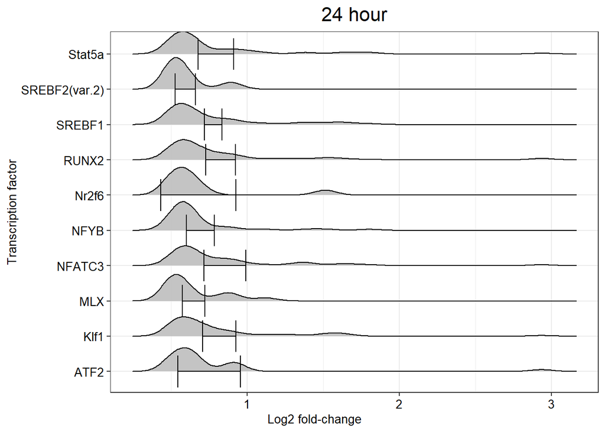

```r
  # Ridgeline_24h_unaffected <-
  ggplot(merged_24_unaffected %>%
         arrange(desc(Significance)) %>%
         filter(TF %in% (merged_24_unaffected %>%
                        arrange(desc(Significance)) %>%
                        distinct(TF) %>%
                        head(10) %>%
                        pull(TF))),
       aes(x = FLAG_24hr.v.FLAG_0hr.logFC, y = TF, fill = Effect)) +
  geom_density_ridges(alpha = 0.9, scale = 0.9) +
 # geom_jitter(aes(color = Effect), size = 0.9, height = 0.1, alpha = 0.6) +
  stat_summary(
    aes(x = FLAG_24hr.v.FLAG_0hr.logFC, y = TF),
    fun.data = "mean_cl_normal",
    geom = "errorbarh",
    height = 0.2,
    color = "black"
  ) +
  scale_fill_manual(values = c("Up" = "grey")) +
  scale_color_manual(values = c("Up" = "black")) +
        ggtitle("24 hour") +
  theme_bw(base_size = 11) +
  theme(
    legend.position = "none",
    axis.title.x = element_text(size = 10, face = "plain", color = "black", hjust = 0.4),
    axis.title.y = element_text(size = 10, face = "plain", color = "black"),
    axis.text.x = element_text(size = 10, face = "plain", color = "black"),
    axis.text.y = element_text(size = 10, face = "plain", color = "black"),
    plot.title = element_text(size = 16, face = "plain", hjust = 0.5, color = "black")
  ) +
  xlab("Log2 fold-change") +
  ylab("Transcription factor")
```

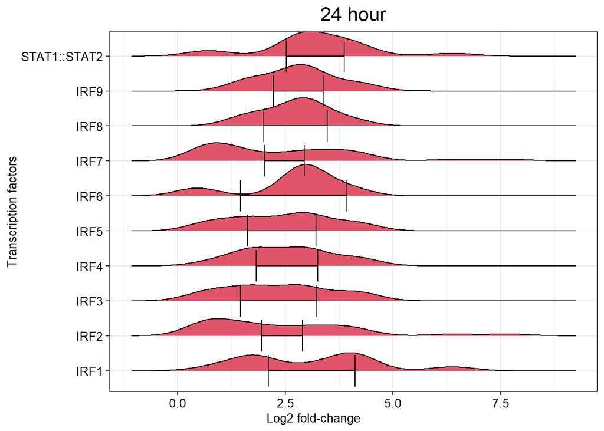

```r
 # Ridgeline_24h_antagonized <-
  ggplot(merged_24_antagonized %>%
         arrange(desc(Significance)) %>%
         filter(TF %in% (merged_24_antagonized %>%
                        arrange(desc(Significance)) %>%
                        distinct(TF) %>%
                        head(10) %>%
                        pull(TF))),
       aes(x = FLAG_24hr.v.FLAG_0hr.logFC, y = TF, fill = Effect)) +
  geom_density_ridges(alpha = 0.9, scale = 0.9) +
 # geom_jitter(aes(color = Effect), size = 0.9, height = 0.1, alpha = 0.6) +
  stat_summary(
    aes(x = FLAG_24hr.v.FLAG_0hr.logFC, y = TF),
    fun.data = "mean_cl_normal",
    geom = "errorbarh",
    height = 0.2,
    color = "black"
  ) +
  scale_fill_manual(values = c("Up" = "#de425b")) +
  scale_color_manual(values = c("Up" = "black")) +
    ggtitle("24 hour") +
  theme_bw(base_size = 11) +
  theme(
    legend.position = "none",
    axis.title.x = element_text(size = 10, face = "plain", color = "black", hjust = 0.4),
    axis.title.y = element_text(size = 10, face = "plain", color = "black"),
    axis.text.x = element_text(size = 10, face = "plain", color = "black"),
    axis.text.y = element_text(size = 10, face = "plain", color = "black"),
    plot.title = element_text(size = 16, face = "plain", hjust = 0.5, color = "black")
  ) +
  xlab("Log2 fold-change") +
  ylab("Transcription factors")
```

```r
circos_merged_1hour_antagonized <- merged_1h_antagonized %>%
  arrange(desc(Significance)) %>%
  filter(TF %in% (merged_1h_antagonized %>%
                 arrange(desc(Significance)) %>%
                 distinct(TF) %>%
                 head(10) %>%
                 pull(TF))) %>%
    dplyr::select(TF, Gene)


circos_merged_1hour_unaffected <- merged_1h_unaffected %>%
  arrange(desc(Significance)) %>%
  filter(TF %in% (merged_1h_unaffected %>%
                 arrange(desc(Significance)) %>%
                 distinct(TF) %>%
                 head(10) %>%
                 pull(TF))) %>%
    dplyr::select(TF, Gene)

circos_merged_6hour_antagonized <- merged_6h_antagonized %>%
  arrange(desc(Significance)) %>%
  filter(TF %in% (merged_6h_antagonized %>%
                 arrange(desc(Significance)) %>%
                 distinct(TF) %>%
                 head(10) %>%
                 pull(TF))) %>%
    dplyr::select(TF, Gene)

circos_merged_6hour_unaffected <- merged_6h_unaffected %>%
  arrange(desc(Significance)) %>%
  filter(TF %in% (merged_6h_unaffected %>%
                 arrange(desc(Significance)) %>%
                 distinct(TF) %>%
                 head(10) %>%
                 pull(TF))) %>%
    dplyr::select(TF, Gene)

circos_merged_24hour_antagonized <- merged_24_antagonized %>%
  arrange(desc(Significance)) %>%
  filter(TF %in% (merged_24_antagonized %>%
                 arrange(desc(Significance)) %>%
                 distinct(TF) %>%
                 head(10) %>%
                 pull(TF))) %>%
    dplyr::select(TF, Gene)

circos_merged_24hour_unaffected <- merged_24_unaffected %>%
  arrange(desc(Significance)) %>%
  filter(TF %in% (merged_24_unaffected %>%
                 arrange(desc(Significance)) %>%
                 distinct(TF) %>%
                 head(10) %>%
                 pull(TF))) %>%
    dplyr::select(TF, Gene)
```

### Chord Plot : TF-Gene regulatory network for ISGs induced post 24h IFN treatment -

```r
circos_merged_24hour_antagonized_downsampled <- circos_merged_24hour_antagonized %>%
  group_by(TF) %>%
  slice_head(n = 30) %>%
  ungroup()
```

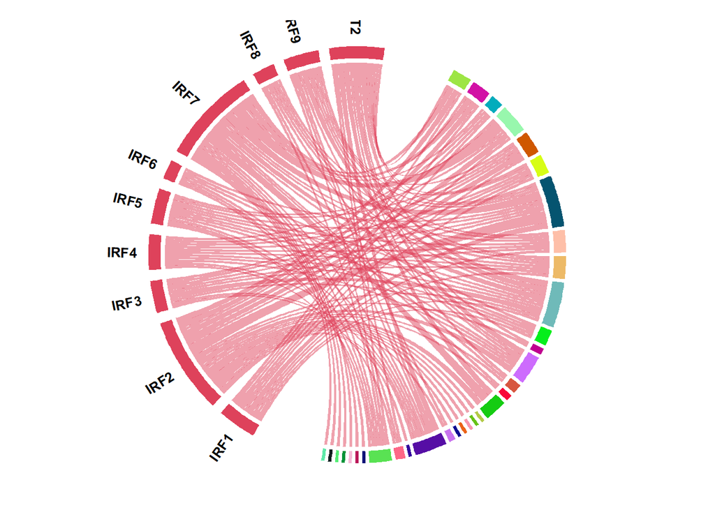

```r
# png("24h_antagonized_circos_plot.png", width = 3000, height = 3000, res = 300)
#png("../results/24h_Antagonized_circos_plot.png", width = 3000, height = 3000, res = 300)

  #p24_A <- as.ggplot(~{
grid.col <- c(
  IRF3 = "#de425b", 'STAT1::STAT2' = "#de425b", IRF8 = "#de425b",
  IRF2 = "#de425b", IRF4 = "#de425b", IRF9 = "#de425b",
  IRF5 = "#de425b", IRF1 = "#de425b",
  IRF6 = "#de425b", IRF7 = "#de425b"
)

# ---- Automatically compute gaps to match dataset
n_TF <- length(unique(circos_merged_24hour_antagonized_downsampled$TF))
n_Gene <- length(unique(circos_merged_24hour_antagonized_downsampled$Gene))
gap.after <- c(rep(3, n_TF - 1), 20, rep(1, n_Gene - 1), 20)
n_sectors <- length(unique(c(circos_merged_24hour_antagonized_downsampled$TF,
                             circos_merged_24hour_antagonized_downsampled$Gene)))

# adjust length automatically if mismatch occurs
if (length(gap.after) != n_sectors) {
  gap.after <- rep(2, n_sectors)
}

# ---- Circos plot
circos.par(track.height = 0.002, start.degree = 240, gap.after = gap.after)

chordDiagram(
  circos_merged_24hour_antagonized_downsampled,
  annotationTrack = "grid",
  grid.col = grid.col,
  preAllocateTracks = list(track.height = 0.01)
)

circos.trackPlotRegion(track.index = 2, panel.fun = function(x, y) {
  xlim <- get.cell.meta.data("xlim")
  ylim <- get.cell.meta.data("ylim")
  sector.name <- get.cell.meta.data("sector.index")

  if (sector.name %in% names(grid.col)) {
    circos.text(
      mean(xlim), ylim[1] + 2, sector.name,
      facing = "clockwise", niceFacing = TRUE,
      adj = c(0, 0.5), cex = 0.8, font = 2
    )
  }
}, bg.border = NA)
```

```r
circos.clear()

#  })

#dev.off()
```

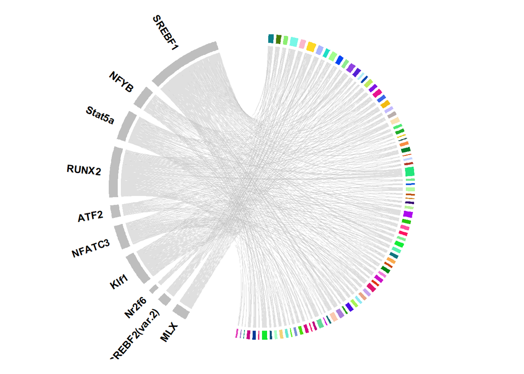

```r
# png("24h_unaffected_circos_plot.png", width = 3000, height = 3000, res = 300)
#png("../results/24h_Unaffected_circos_plot.png", width = 3000, height = 3000, res = 300)

  # p24_U <- as.ggplot(~{
grid.col <- c(
  MLX = "grey", 'SREBF2(var.2)' = "grey", Nr2f6 = "grey",
  Klf1 = "grey", NFATC3 = "grey", ATF2 = "grey",
  RUNX2 = "grey", Stat5a = "grey",
  NFYB = "grey", SREBF1 = "grey"
)

# ---- Automatically compute gaps to match dataset
n_TF <- length(unique(circos_merged_24hour_unaffected$TF))
n_Gene <- length(unique(circos_merged_24hour_unaffected$Gene))
gap.after <- c(rep(3, n_TF - 1), 20, rep(1, n_Gene - 1), 20)
n_sectors <- length(unique(c(circos_merged_24hour_unaffected$TF,
                             circos_merged_24hour_unaffected$Gene)))

# adjust length automatically if mismatch occurs
if (length(gap.after) != n_sectors) {
  gap.after <- rep(2, n_sectors)
}

# ---- Circos plot
circos.par(track.height = 0.002, start.degree = 240, gap.after = gap.after)

chordDiagram(
  circos_merged_24hour_unaffected,
  annotationTrack = "grid",
  grid.col = grid.col,
  preAllocateTracks = list(track.height = 0.01)
)

circos.trackPlotRegion(track.index = 2, panel.fun = function(x, y) {
  xlim <- get.cell.meta.data("xlim")
  ylim <- get.cell.meta.data("ylim")
  sector.name <- get.cell.meta.data("sector.index")

  if (sector.name %in% names(grid.col)) {
    circos.text(
      mean(xlim), ylim[1] + 2, sector.name,
      facing = "clockwise", niceFacing = TRUE,
      adj = c(0, 0.5), cex = 0.8, font = 2
    )
  }
}, bg.border = NA)
```

```r
circos.clear()

# })

#dev.off()
```

# Experimental support for TF predictions

“scripts/18_Multiple_Filter_Bedfile.py”

Usage with example

```python
import pandas as pd
import re
import os

def sanitize_filename(filename):
    # Replace invalid characters with underscores
    return re.sub(r'[\\/*?:"<>|]', "_", filename)

def filter_bed_by_multiple_tfs(input_file, tf_dict):
    # Read the BED file
    df = pd.read_csv(input_file, sep='\t', header=None,
                     names=['chr', 'start', 'end', 'name', 'score', 'strand',
                            'thickStart', 'thickEnd', 'itemRgb'])

    # Filter and save for each TF
    for tf, ids in tf_dict.items():
        # Create a pattern that matches the TF name or any of its IDs
        pattern = '|'.join([re.escape(tf)] + [re.escape(id) for id in ids])

        # Filter the dataframe
        filtered_df = df[df['name'].str.contains(pattern, regex=True)]

        # Create sanitized output filename
        output_file = sanitize_filename(f"{tf}.filtered.bed")

        # Write the filtered data to a new BED file
        filtered_df.to_csv(output_file, sep='\t', header=False, index=False)

        print(f"Filtered BED file created for {tf}: {output_file}")

# Usage
tf_dict = {
    'MLX': ['MA0663.1'],
    'SREBF2(var.2)': ['MA0828.1'],
    'Nr2f6': ['MA0677.1'],
    'Klf1': ['MA0493.1'],
    'NFATC3': ['MA0625.1'],
    'ATF2': ['MA1632.1'],
    'RUNX2': ['MA0511.2'],
    'Stat5a': ['MA1624.1'],
    'NFYB': ['MA0502.2'],
    'SREBF1': ['MA0595.1']

    # Add more TF name: [TF_ID list] pairs as needed
}

filter_bed_by_multiple_tfs('../results/CiiiDER_Predictions/bed/IFN-Induced-Unaffected-24hr_CurrentSites.bed', tf_dict)
```

Datasets from ENCODE and UNIBIND for each of the predicted Transcription factors were retrieved. For ENCODE data sets (https://www.encodeproject.org/) each of predicted transcription factors were searched manually, those with experiment status flagged as **released** and replicate concordance confirmed by IDR (Irreproducible Discovery Rate) < 0.05 with Corresponding optimal IDR peak files (narrowPeak format) were downloaded. For UniBIND (https://unibind.uio.no/) cis-Regulatory modules for species Homo sapiens in the ROBUST collection were downloaded in bed format. For ReMap2022 (https://remap.univ-amu.fr) Non redundant peaks for Homosapiens were downloaded.

Overlap analysis between input filtered bed files against experimental verified bed files from ENCODE/UniBind was run using the following python scripts

“scripts/19_Per_TF_ENCODE_CiiiDER_Overlap”) “scripts/20_Per_TF_UniBind_CiiiDER_Overlap”)

for ENCODE datasets

```python
import os
import subprocess
import pandas as pd

def run_bedtools_intersect(query_file, database_file, output_file):
    command = f"bedtools intersect -a {query_file} -b {database_file} -wa -wb -f 0.5 > {output_file}"
    subprocess.run(command, shell=True, check=True)

def calculate_overlap(intersect_file, query_file):
    try:
        df = pd.read_csv(intersect_file, sep='\t', header=None)
        total_query_regions = len(pd.read_csv(query_file, sep='\t', header=None))
        if df.empty:
            return 0, total_query_regions, 0
        overlapping_regions = df[3].nunique()
        percent_overlap = (overlapping_regions / total_query_regions) * 100
        return overlapping_regions, total_query_regions, percent_overlap
    except pd.errors.EmptyDataError:
        total_query_regions = len(pd.read_csv(query_file, sep='\t', header=None))
        return 0, total_query_regions, 0

def process_tf_folder(query_file, tf_folder, tf_name):
    results = []
    for file in os.listdir(tf_folder):
        if file.endswith('.bed'):
            database_file = os.path.join(tf_folder, file)
            output_file = f"{os.path.basename(query_file)}_{tf_name}_{file}_intersect_result.txt"
            run_bedtools_intersect(query_file, database_file, output_file)

            overlapping, total, percent = calculate_overlap(output_file, query_file)
            results.append({
                'Query': os.path.basename(query_file),
                'Database': file,
                'Overlapping Regions': overlapping,
                'Total Query Regions': total,
                'Percent Overlap': percent
            })

            os.remove(output_file)  # Clean up temporary file

    return pd.DataFrame(results)

# Set the paths
query_folders = ["1hr_antagonized", "1hr_unaffected", "24hr_antagonized", "24hr_unaffected", "6hr_antagonized", "6hr_unaffected"]
comparison_dir = "."  # Current directory

# Specify the transcription factors to include in the analysis
tfs_to_analyze = ["ATF1", "ATF2", "ATF3", "CREB1", "EBF1", "HSF1", "HSF2", "HSF4", "JUN", "JUND", "KLF16", "PAX5", "RUNX1", "TAL1", "ZNF341"]

# Process each query folder
for query_folder in query_folders:
    # Get all .bed files in the query folder that match the specified TFs
    query_files = [f for f in os.listdir(query_folder) if f.endswith('.filtered.bed') and f.split('.')[0] in tfs_to_analyze]

    for query_file in query_files:
        # Extract TF name from the query file (e.g., 'PAX5' from 'PAX5.filtered.bed')
        tf_name = query_file.split('.')[0]

        query_path = os.path.join(query_folder, query_file)
        tf_folder = os.path.join(comparison_dir, tf_name)

        if os.path.exists(tf_folder):
            results_df = process_tf_folder(query_path, tf_folder, tf_name)
            print(f"\nResults for {query_folder}/{query_file} vs {tf_name}:")
            if results_df.empty:
                print("No overlaps found for any database files.")
            else:
                print(results_df.to_string(index=False))

            # Optionally, save results to a CSV file
            results_df.to_csv(f"{query_folder}_{query_file}_{tf_name}_overlap_results.csv", index=False)
        else:
            print(f"Folder for {tf_name} not found in comparison directory")

print("\nOverlap analysis completed.")
```

for UniBind datasets

```python
import os
import subprocess
import pandas as pd

def run_bedtools_intersect(query_file, database_file, output_file):
    command = f"bedtools intersect -a {query_file} -b {database_file} -wa -wb -f 0.5 > {output_file}"
    subprocess.run(command, shell=True, check=True)

def calculate_overlap(intersect_file, query_file):
    try:
        df = pd.read_csv(intersect_file, sep='\t', header=None)
        total_query_regions = len(pd.read_csv(query_file, sep='\t', header=None))
        if df.empty:
            return 0, total_query_regions, 0
        overlapping_regions = df[3].nunique()
        percent_overlap = (overlapping_regions / total_query_regions) * 100
        return overlapping_regions, total_query_regions, percent_overlap
    except pd.errors.EmptyDataError:
        total_query_regions = len(pd.read_csv(query_file, sep='\t', header=None))
        return 0, total_query_regions, 0

def process_folder(query_file, folder_path, tf_name):
    results = []
    for file in os.listdir(folder_path):
        if file.endswith('.bed'):
            database_file = os.path.join(folder_path, file)
            output_file = f"{os.path.basename(query_file)}_{tf_name}_{file}_intersect_result.txt"
            run_bedtools_intersect(query_file, database_file, output_file)

            overlapping, total, percent = calculate_overlap(output_file, query_file)
            results.append({
                'Query': os.path.basename(query_file),
                'Database': file,
                'Overlapping Regions': overlapping,
                'Total Query Regions': total,
                'Percent Overlap': percent
            })

            os.remove(output_file)  # Clean up temporary file

    return pd.DataFrame(results)

# Set the paths
query_folders = ["24hr_unaffected"]
comparison_dir = "Validate_CiiiDER_UniBind/Comparison"

# Specify the transcription factors to include in the analysis
tfs_to_analyze = ["JUND", "JUN", "CREB1"]  # Add or remove TFs as needed

# Process each query folder
for query_folder in query_folders:
    # Get all .bed files in the query folder that match the specified TFs
    query_files = [f for f in os.listdir(query_folder) if f.endswith('.filtered.bed') and f.split('.')[0] in tfs_to_analyze]

    for query_file in query_files:
        # Extract TF name from the query file (e.g., 'PAX5' from 'PAX5.filtered.bed')
        tf_name = query_file.split('.')[0]

        query_path = os.path.join(query_folder, query_file)
        tf_folder = os.path.join(comparison_dir, tf_name)

        if os.path.exists(tf_folder):
            results_df = process_folder(query_path, tf_folder, tf_name)
            print(f"\nResults for {query_folder}/{query_file} vs {tf_name}:")
            if results_df.empty:
                print("No overlaps found for any database files.")
            else:
                print(results_df.to_string(index=False))

            # Optionally, save results to a CSV file
            results_df.to_csv(f"{query_folder}_{query_file}_{tf_name}_overlap_results.csv", index=False)
        else:
            print(f"Folder for {tf_name} not found in Comparison directory")

print("\nOverlap analysis completed.")
```